# Data Ingestion – Tabular Formats

*Tidy datasets are all alike, but every messy dataset is messy in its own way.*

Hadley Wickham (cf. Leo Tolstoy)

A great deal of data both does and should live in tabular formats; to put it flatly, this means formats that have rows and columns. In a theoretical sense, it is possible to represent *every* collection of *structured data* in terms of multiple "flat" or "tabular" collections if we also have a concept of *relations*. Relational database management systems (RDBMS) have had a great deal of success since 1970, and a very large part of all the world's data lives in RDBMS's. Another large share lives in formats that are not relational as such, but that are nonetheless tabular, wherein relationships may be *imputed* in an ad hoc, but uncumbersome, way.

This lesson discusses tabular formats including CSV, spreadsheets, and SQL databases. *Remediating* characteristic problems is largely left until later chapters; detecting them is this lesson's focus of attention. A variety of libraries and data sets are loaded prior to the code slides that follow.

```python
# Tidying up
students = pl.read_csv("data/students-scores.csv")
students
```

shape: (6, 5)

| Last Name str | First Name str | 4th Grade str | 5th Grade str | 6th Grade str |
| --- | --- | --- | --- | --- |
| "Johnson" | "Mia" | "A" | "B+" | "A-" |
| "Lopez" | "Liam" | "B" | "B" | "A+" |
| "Lee" | "Isabella" | "C" | "C-" | "B-" |
| "Fisher" | "Mason" | "B" | "B-" | "C+" |
| "Gupta" | "Olivia" | "B" | "A+" | "A" |
| "Robinson" | "Sophia" | "A+" | "B-" | "A" |

```python
# Massage the DataFrame
to_num = {'A+': 4.3, 'A': 4, 'A-': 3.7,
          'B+': 3.3, 'B': 3, 'B-': 2.7,
          'C+': 2.3, 'C': 2, 'C-': 1.7}
df = (students.with_columns(
    pl.col("4th Grade").replace(to_num, default=None),
    pl.col("5th Grade").replace(to_num, default=None),
    pl.col("6th Grade").replace(to_num, default=None)
)
    .drop(["First Name", "Last Name"])
    .transpose(include_header=False,
               column_names=students["Last Name"])
)
df
```

shape: (3, 6)

| Johnson f64 | Lopez f64 | Lee f64 | Fisher f64 | Gupta f64 | Robinson f64 |
| --- | --- | --- | --- | --- | --- |
| 4.0 | 3.0 | 2.0 | 3.0 | 3.0 | 4.3 |
| 3.3 | 3.0 | 1.7 | 2.7 | 4.3 | 2.7 |
| 3.7 | 4.3 | 2.7 | 2.3 | 4.0 | 4.0 |

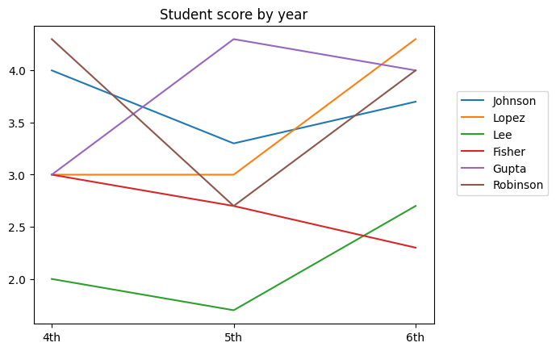

```python
for student in students["Last Name"]:
    plt.plot(["4th", "5th", "6th"], df[student], label=student)
plt.legend(loc="upper right", bbox_to_anchor=(1.3, .80));
plt.title("Student score by year");
```

## CSV

Delimited text files, especially comma-separated-value files, are ubiquitous. These contain multiple values on each line, and separate those values with some semi-reserved character, such as a comma. Delimited files are commonly used to transport data between other tabular representations

### Sanity Checks

Suppose you have just received a medium sized CSV file, and you want to make a quick sanity check on it. At this stage, you are concerned about whether the file is formatted correctly at all. We can try to read the file using, for example, Pandas and Polars, and we see fairly helpful errors.

```python
# Use try/except to avoid full traceback in example
try:
    pd.read_csv('data/big-random.csv')
except Exception as err:
    print_err(err)
```

```
ParserError
Error tokenizing data. C error: Expected 6 fields in line 75, saw 8
```

```python
try:
    pl.read_csv('data/big-random.csv')
except Exception as err:
    print_err(err)
```

```
ComputeError
found more fields than defined in 'Schema'  Consider setting
'truncate_ragged_lines=True'.
```

```python
%%bash
# What is the general size/shape of this file?
wc data/big-random.csv
```

```
 100000  100000 4335846 data/big-random.csv
```

```python
%%bash
cat data/big-random.csv |
    tr -d -c ',\n' |          # remove everything not comma or newline
    awk '{ print length; }' | # print the length of trimmed line
    sort |                    # sort all those lengths
    uniq -c                   # histogram of lengths
```

```
     46 3
  99909 5
     45 7
```

```python
%%bash
grep -C1 -nP '^([^,]+,){7}' data/big-random.csv | head -11
```

```
74-squarcerai,45,quiescenze,12,scuoieremo,70
75:fantasmagorici,28,immischiavate,44,schiavizzammo,97,sfilzarono,49
76-interagiste,50,repentagli,72,attendato,95
--
712-resettando,58,strisciato,46,insaldai,62
713:aspirasse,15,imbozzimatrici,70,incanalante,93,succhieremo,41
714-saccarometriche,18,stremaste,12,hindi,19
--
8096-squincio,16,biascicona,93,solisti,70
8097:rinegoziante,50,circoncidiamo,83,stringavate,79,stipularono,34
8098-disaeriamo,94,sfiorisce,37,mesterebbe,46
```

```python
import io
buff = io.StringIO()
for line in open('data/big-random.csv'):
    if line.count(",") == 5:
        buff.write(line)
buff.seek(0)
pl.read_csv(buff, has_header=False)
```

shape: (99_909, 6)

| column_1 str | column_2 i64 | column_3 str | column_4 i64 | column_5 str | column_6 i64 |
| --- | --- | --- | --- | --- | --- |
| "infilaste" | 21 | "esemplava" | 15 | "stabaccavo" | 73 |
| "abbadaste" | 50 | "enartrosi" | 85 | "iella" | 54 |
| "frustulo" | 77 | "temporale" | 83 | "scoppianti" | 91 |
| "gavocciolo" | 84 | "postelegrafiche" | 93 | "inglesizzanti" | 63 |
| "svani" | 92 | "spiombasti" | 99 | "aderisce" | 74 |
| … | … | … | … | … | … |
| "rattralciassi" | 12 | "riflessogeni" | 65 | "rinvanghiate" | 90 |
| "notareschi" | 60 | "paganico" | 64 | "esecutavamo" | 20 |
| "rispranghiamo" | 11 | "schioccano" | 44 | "imbozzarono" | 80 |
| "compone" | 85 | "disfronderebbe" | 19 | "vaporizzavo" | 54 |
| "ritardata" | 29 | "scordare" | 43 | "appuntirebbe" | 24 |

### The Good, The Bad, and The Textual Data

Textual data files have advantages and disadvantages. Delimited files use a *delimiter*, as the name suggests, while fixed width files use specific offsets. Let's discuss some advantages and disadvantages.

**The Bad**

Columns in delimited or flat files do not carry a data type, being simply text values. Many tools will (optionally) make guesses about the data type, but these are subject to pitfalls. Even where the tools accurately guess the broad type category they cannot guess the specific bit lengths desired.

```python
%%bash
cat data/parts.fwf
```

```
Part_No  Description              Maker               Price (USD)
12345    Wankle rotary engine     Acme Corporation    555.55
67890    Sousaphone               Marching Inc.       333.33
2468     Feather Duster           Sweeps Bros         22.22
A9922    Area 51 metal fragment   No Such Agency      9999.99
```

Reading this with Pandas correctly infers the intended column positions for the fields.

```python
df = pd.read_fwf('data/parts.fwf', nrows=3)
df
```

|  | Part_No | Description | Maker | Price (USD) |
| --- | --- | --- | --- | --- |
| 0 | 12345 | Wankle rotary engine | Acme Corporation | 555.55 |
| 1 | 67890 | Sousaphone | Marching Inc. | 333.33 |
| 2 | 2468 | Feather Duster | Sweeps Bros | 22.22 |

```python
df.dtypes
```

```
Part_No          int64
Description     object
Maker           object
Price (USD)    float64
dtype: object
```

```python
df = pd.read_fwf('data/parts.fwf')
df
```

|  | Part_No | Description | Maker | Price (USD) |
| --- | --- | --- | --- | --- |
| 0 | 12345 | Wankle rotary engine | Acme Corporation | 555.55 |
| 1 | 67890 | Sousaphone | Marching Inc. | 333.33 |
| 2 | 2468 | Feather Duster | Sweeps Bros | 22.22 |
| 3 | A9922 | Area 51 metal fragment | No Such Agency | 9999.99 |

```python
df.dtypes  # type of `Part_No` changed
```

```
Part_No         object
Description     object
Maker           object
Price (USD)    float64
dtype: object
```

```python
%%bash
# Notice many date formats
cat data/parts.tsv
```

```
Part_No	Description	Date	Price (USD)
12345	Wankle rotary	2020-04-12T15:53:21	555.55
67890	Sousaphone	April 12, 2020	333.33
2468	Feather Duster	4/12/2020	22.22
A9922	Area 51 metal	04/12/20	9999.99
```

```python
parts = pd.read_csv('data/parts.tsv', sep='\t')
# Let Pandas make guesses for each row; VERY SLOW for large tables
parts['Date'] = pd.to_datetime(parts.Date, format="mixed").dt.date
parts
```

|  | Part_No | Description | Date | Price (USD) |
| --- | --- | --- | --- | --- |
| 0 | 12345 | Wankle rotary | 2020-04-12 | 555.55 |
| 1 | 67890 | Sousaphone | 2020-04-12 | 333.33 |
| 2 | 2468 | Feather Duster | 2020-04-12 | 22.22 |
| 3 | A9922 | Area 51 metal | 2020-04-12 | 9999.99 |

**The Good**

The biggest strength of delimited and fixed-width formats is the ubiquity of tools to read and write them. Every dataframe and array library, across every programming language, handles them. Every spreadsheet program imports and exports as CSV. Every RDBMS imports and exports as CSV. Most programming text editors have facilities to make editing CSV easier.

## Spreadsheets Considered Harmful

- Non-enforced field/column identity
- Computational opacity
- Semi-tabular data
- Non-contiguous data
- Invisible data and data type discrepancies
- User interface as attractive nuisance

### Computational opacity

In a "regular" computer program, the flow of computation is relatively straightforward. In spreadsheets, computation is hidden within a non-obvious flow among many cells, across many sheets, and the distinction between computed versus observed data is greatly obscured.

[figure not shown]

```python
pd.read_excel('data/Excel-Pitfalls.xlsx',
              sheet_name="Dask Sample", engine="openpyxl")
```

|  | timestamp | id | name | x |
| --- | --- | --- | --- | --- |
| 0 | 2000-01-01 00:00:00 | 979 | Zelda | 0.802163 |
| 1 | 2000-01-01 0:00:01 | 1019.5 | Ingrid | -0.349999 |
| 2 | 2000-01-01 00:00:02 | 1007 | Hannah | -0.169853 |
| 3 | 2000-01-01 00:00:03 | 1034 | Ursula | 0.86809 |
| 4 |  | NaN | NaN | NaN |
| 5 | NaN | NaN | NaN | NaN |
| 6 | timestamp | id | name | y |
| 7 | 2000-01-01 00:00:02 | 1007 | Hannah | -0.050842 |
| 8 | 2000-01-01 00:00:03 | 1034 | Ursula | -0.190783 |
| 9 | 2000-01-01 00:00:04 | 1024 | Ingrid | 0.109101 |

```python
df1 = pd.read_excel('data/Excel-Pitfalls.xlsx',
                    nrows=5, dtype=object, engine="openpyxl")
df1.loc[:2]   # Just look at first few rows
```

|  | timestamp | id | name | x |
| --- | --- | --- | --- | --- |
| 0 | 2000-01-01 00:00:00 | 979 | Zelda | 0.802163 |
| 1 | 2000-01-01 0:00:01 | 1019.5 | Ingrid | -0.349999 |
| 2 | 2000-01-01 00:00:02 | 1007 | Hannah | -0.169853 |

```python
pd.read_excel('data/Excel-Pitfalls.xlsx', skiprows=7, engine="openpyxl")
```

|  | timestamp | id | name | y |
| --- | --- | --- | --- | --- |
| 0 | 2000-01-01 00:00:02 | 1007 | Hannah | -0.050842 |
| 1 | 2000-01-01 00:00:03 | 1034 | Ursula | -0.190783 |
| 2 | 2000-01-01 00:00:04 | 1024 | Ingrid | 0.109101 |

```python
df1.dtypes
```

```
timestamp    object
id           object
name         object
x            object
dtype: object
```

```python
# Look at the stored data type of each cell
tss = df1.loc[:2, 'timestamp']
for i, ts in enumerate(tss):
    print(f"TS {i}: {ts}\t{ts.__class__.__name__}")
```

```
TS 0: 2000-01-01 00:00:00	datetime
TS 1: 2000-01-01 0:00:01	str
TS 2: 2000-01-01 00:00:02	datetime
```

```python
pd.to_datetime(tss)
```

```
0   2000-01-01 00:00:00
1   2000-01-01 00:00:01
2   2000-01-01 00:00:02
Name: timestamp, dtype: datetime64[ns]
```

```python
# Look at the stored data type of each cell
ids = df1.loc[:3, 'id']
for i, id_ in enumerate(ids):
    print(f"id {i}: {id_}\t{id_.__class__.__name__}")
```

```
id 0: 979	int
id 1: 1019.5	float
id 2: 1007	int
id 3: 1034	str
```

```python
df1 = df1.loc[0:3].astype(
    {'id': np.uint16,
     'name': pd.StringDtype(),
     'x': float})
# datetimes require conversion function, not just type
df1['timestamp'] = pd.to_datetime(df1.timestamp)
df1.dtypes
```

```
timestamp    datetime64[ns]
id                   uint16
name         string[python]
x                   float64
dtype: object
```

```python
df1.set_index('timestamp')
```

| timestamp | id | name | x |
| --- | --- | --- | --- |
| 2000-01-01 00:00:00 | 979 | Zelda | 0.802163 |
| 2000-01-01 00:00:01 | 1019 | Ingrid | -0.349999 |
| 2000-01-01 00:00:02 | 1007 | Hannah | -0.169853 |
| 2000-01-01 00:00:03 | 1034 | Ursula | 0.868090 |

## Denouement

*All models are wrong, but some models are useful.*

George Box